# Practical J: Solutions

Model estimation

Maarten Cruyff

```r
library(MASS)
library(ggplot2)
library(dplyr)
library(gridExtra)
```

# The Diamonds data

In this exercise, predict the price of diamonds from a continuous and categorical variable. The data set is `diamonds` of the package `ggplot2`, The data set is very large, so we will work with a random sample of 500 cases.

First have a look at the structure of the data set with: `str()`. What do you conclude? Which data types do you see?

```r
str(diamonds)
```

```
## tibble [53,940 × 10] (S3: tbl_df/tbl/data.frame)
##  $ carat  : num [1:53940] 0.23 0.21 0.23 0.29 0.31 0.24 0.24 0.26 0.22 0.23 ...
##  $ cut    : Ord.factor w/ 5 levels "Fair"<"Good"<..: 5 4 2 4 2 3 3 3 1 3 ...
##  $ color  : Ord.factor w/ 7 levels "D"<"E"<"F"<"G"<..: 2 2 2 6 7 7 6 5 2 5 ...
##  $ clarity: Ord.factor w/ 8 levels "I1"<"SI2"<"SI1"<..: 2 3 5 4 2 6 7 3 4 5 ...
##  $ depth  : num [1:53940] 61.5 59.8 56.9 62.4 63.3 62.8 62.3 61.9 65.1 59.4 ...
##  $ table  : num [1:53940] 55 61 65 58 58 57 57 55 61 61 ...
##  $ price  : int [1:53940] 326 326 327 334 335 336 336 337 337 338 ...
##  $ x      : num [1:53940] 3.95 3.89 4.05 4.2 4.34 3.94 3.95 4.07 3.87 4 ...
##  $ y      : num [1:53940] 3.98 3.84 4.07 4.23 4.35 3.96 3.98 4.11 3.78 4.05 ...
##  $ z      : num [1:53940] 2.43 2.31 2.31 2.63 2.75 2.48 2.47 2.53 2.49 2.39 ...
```

1. Set the seed to 100 and—with the help of pipe operators—use the `slice_sample()` function to take a random sample form the original data set. Call the new data set: `my_diamonds`, Change the class of the variables `cut`, `color` and `clarity` from `ordered factor` to `factor`. Look again at the results with `str()` and `summary()`.

```r
set.seed(100)
my_diamonds <- dplyr::slice_sample(diamonds, n = 500, replace = TRUE) %>%
  dplyr::mutate(cut = factor(cut, ordered = FALSE),
         color   = factor(color, ordered = FALSE),
         clarity = factor(clarity, ordered = FALSE))

str(my_diamonds)
```

```
## tibble [500 × 10] (S3: tbl_df/tbl/data.frame)
##  $ carat  : num [1:500] 1.26 0.7 0.36 2.1 1.21 2 0.4 1.02 0.61 0.55 ...
##  $ cut    : Factor w/ 5 levels "Fair","Good",..: 5 5 5 4 4 2 5 3 3 5 ...
##  $ color  : Factor w/ 7 levels "D","E","F","G",..: 4 1 3 7 1 2 3 2 4 4 ...
##  $ clarity: Factor w/ 8 levels "I1","SI2","SI1",..: 3 4 3 2 2 2 7 8 3 5 ...
##  $ depth  : num [1:500] 59.6 62.7 62 59.1 59.7 64.7 61.7 58.1 62 61.6 ...
##  $ table  : num [1:500] 57 57 56 58 58 57 57 59 58 55 ...
##  $ price  : int [1:500] 6738 3448 770 12494 4946 15393 1446 11420 1659 1786 ...
##  $ x      : num [1:500] 7.08 5.65 4.59 8.46 7.06 7.75 4.74 6.71 5.43 5.29 ...
##  $ y      : num [1:500] 7.04 5.67 4.54 8.4 6.96 7.86 4.7 6.75 5.48 5.32 ...
##  $ z      : num [1:500] 4.21 3.55 2.83 4.98 4.19 5.05 2.91 3.91 3.38 3.27 ...
```

```r
summary(my_diamonds)
```

```
##      carat               cut      color      clarity        depth
##  Min.   :0.2300   Fair     : 12   D: 53   SI1    :117   Min.   :56.20
##  1st Qu.:0.4000   Good     : 41   E:102   VS2    :107   1st Qu.:61.10
##  Median :0.7000   Very Good:120   F: 90   SI2    : 94   Median :61.90
##  Mean   :0.8069   Premium  :123   G: 97   VS1    : 78   Mean   :61.76
##  3rd Qu.:1.1000   Ideal    :204   H: 85   VVS2   : 51   3rd Qu.:62.50
##  Max.   :2.5400                   I: 46   VVS1   : 38   Max.   :68.40
##                                   J: 27   (Other): 15
##      table           price               x               y
##  Min.   :52.80   Min.   :  354.0   Min.   :3.940   Min.   :3.900
##  1st Qu.:56.00   1st Qu.:  972.8   1st Qu.:4.718   1st Qu.:4.718
##  Median :57.00   Median : 2304.5   Median :5.655   Median :5.675
##  Mean   :57.23   Mean   : 4075.1   Mean   :5.749   Mean   :5.751
##  3rd Qu.:59.00   3rd Qu.: 5677.5   3rd Qu.:6.643   3rd Qu.:6.622
##  Max.   :65.00   Max.   :18678.0   Max.   :8.820   Max.   :8.760
##
##        z
##  Min.   :2.410
##  1st Qu.:2.917
##  Median :3.510
##  Mean   :3.550
##  3rd Qu.:4.090
##  Max.   :5.550
##
```

## Presentation ready summary tables

The package [`gtsummary`](https://www.danieldsjoberg.com/gtsummary/) provides a flexible way to create presentation-ready summary tables. Have a look at the webpage of this package to learn more about the possibilities. Install the package `gtsummary` and load it.

Make a `gtsummary` table of the `my_diamonds` data with the following code: `my_diamonds %>% tbl_summary()`

```r
# install.packages("gtsummary")
require(gtsummary)

my_diamonds %>% tbl_summary()
```

| **Characteristic** | **N = 500**<sup>1</sup> |
| --- | --- |
| carat | 0.70 (0.40, 1.10) |
| cut |  |
| Fair | 12 (2.4%) |
| Good | 41 (8.2%) |
| Very Good | 120 (24%) |
| Premium | 123 (25%) |
| Ideal | 204 (41%) |
| color |  |
| D | 53 (11%) |
| E | 102 (20%) |
| F | 90 (18%) |
| G | 97 (19%) |
| H | 85 (17%) |
| I | 46 (9.2%) |
| J | 27 (5.4%) |
| clarity |  |
| I1 | 2 (0.4%) |
| SI2 | 94 (19%) |
| SI1 | 117 (23%) |
| VS2 | 107 (21%) |
| VS1 | 78 (16%) |
| VVS2 | 51 (10%) |
| VVS1 | 38 (7.6%) |
| IF | 13 (2.6%) |
| depth | 61.90 (61.10, 62.50) |
| table | 57.00 (56.00, 59.00) |
| price | 2,304 (973, 5,678) |
| x | 5.66 (4.72, 6.64) |
| y | 5.68 (4.72, 6.62) |
| z | 3.51 (2.92, 4.09) |

<sup>1</sup> Median (IQR); n (%)

Make a scatterplot with `ggplot` with the following aesthetics: x-axis = `carat`; y-axis = `price`; color = `depth` and add a meaningful main title to the plot, as well as axis lables. What do you conclude?

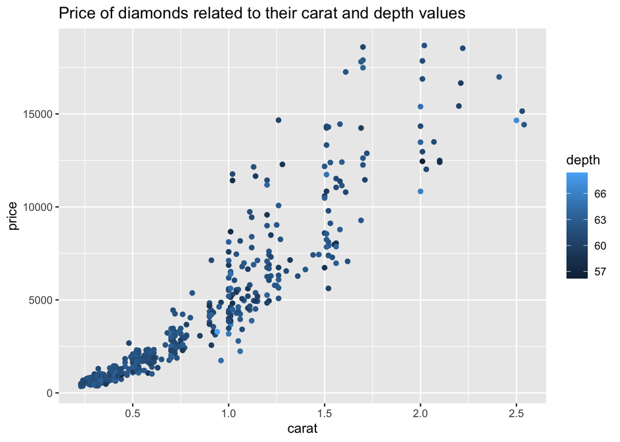

```r
p <- ggplot(my_diamonds, aes(x=carat, y=price, color=depth)) +
      geom_point() +
      labs(x = "carat", y = "price", title = "Price of diamonds related to their carat and depth values")
p
```

## Numeric predictors

We start with a simple regression predicting the `price` of diamonds from the numeric predictor `carat`.

1. Display a scatter plot of `price` against `carat`, and add a linear regression line (set the size of the points to 0.5).

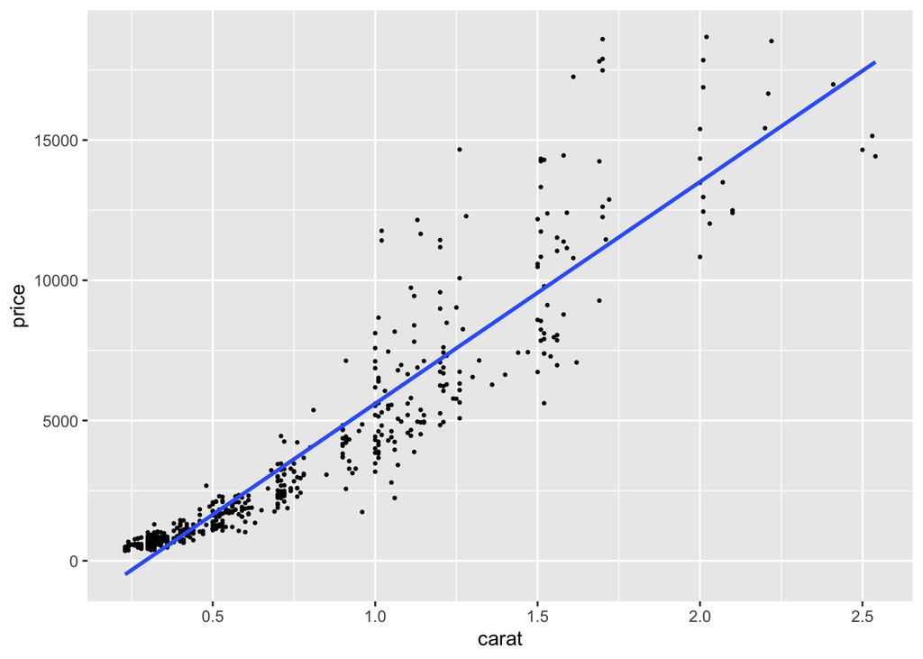

```r
ggplot(my_diamonds, aes(x = carat, y = price)) +
  geom_point(size = 0.5) +
  geom_smooth(method = "lm", se = FALSE)
```

2. Describe the effect of `carat` on `price`.
- `carat` is positively associated with `price`.
3. Display and interpret the summary of the model.

```r
fit <- lm(price ~ carat, my_diamonds)
fit %>% summary()
```

```
##
## Call:
## lm(formula = price ~ carat, data = my_diamonds)
##
## Residuals:
##     Min      1Q  Median      3Q     Max
## -4097.8  -858.6   -73.8   534.8  7458.3
##
## Coefficients:
##             Estimate Std. Error t value Pr(>|t|)
## (Intercept)  -2307.6      136.6  -16.90   <2e-16 ***
## carat         7910.2      145.0   54.57   <2e-16 ***
## ---
## Signif. codes:  0 '***' 0.001 '**' 0.01 '*' 0.05 '.' 0.1 ' ' 1
##
## Residual standard error: 1577 on 498 degrees of freedom
## Multiple R-squared:  0.8567, Adjusted R-squared:  0.8564
## F-statistic:  2978 on 1 and 498 DF,  p-value: < 2.2e-16
```

4. Test the significance of the model against the intercept-only model.

```r
anova(lm(price ~ 1, my_diamonds), fit)
```

```
## Analysis of Variance Table
##
## Model 1: price ~ 1
## Model 2: price ~ carat
##   Res.Df        RSS Df Sum of Sq    F    Pr(>F)
## 1    499 8643336276
## 2    498 1238309642  1 7.405e+09 2978 < 2.2e-16 ***
## ---
## Signif. codes:  0 '***' 0.001 '**' 0.01 '*' 0.05 '.' 0.1 ' ' 1
```

5. Display and interpret a the residual plots of the model.

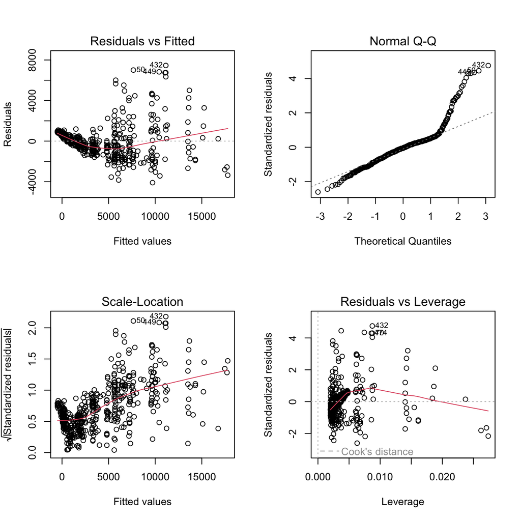

```r
par(mfrow = c(2, 2))
plot(fit)
```

## Categorical predictor

We now predict the `price` of diamonds from the categorical predictors `cut`. The variable `cut` in this data set has class `ordered` (the class for ordinal variables), but, for this practical, we want it to have class `factor` (the class for categorical variables).

1. Display boxplots of `price` for the different levels of `cut` with `ggplot`. Interpret the results.

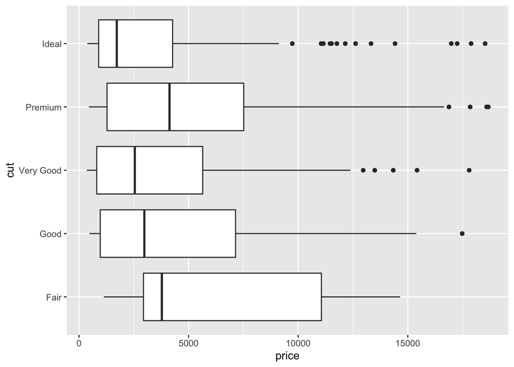

```r
my_diamonds %>%
  ggplot(aes(price, cut)) +
  geom_boxplot()
```

2. Display and interpret the summary of the model with `cut` predicting `price`.

```r
fit <- lm(price ~ cut, my_diamonds)
fit %>% summary()
```

```
##
## Call:
## lm(formula = price ~ cut, data = my_diamonds)
##
## Residuals:
##    Min     1Q Median     3Q    Max
##  -5132  -2599  -1478   1668  15326
##
## Coefficients:
##              Estimate Std. Error t value Pr(>|t|)
## (Intercept)    6266.2     1176.9   5.324 1.54e-07 ***
## cutGood       -1738.5     1338.1  -1.299   0.1945
## cutVery Good  -2367.0     1234.3  -1.918   0.0557 .
## cutPremium     -941.4     1233.0  -0.764   0.4455
## cutIdeal      -3060.9     1211.0  -2.528   0.0118 *
## ---
## Signif. codes:  0 '***' 0.001 '**' 0.01 '*' 0.05 '.' 0.1 ' ' 1
##
## Residual standard error: 4077 on 495 degrees of freedom
## Multiple R-squared:  0.04815,    Adjusted R-squared:  0.04045
## F-statistic: 6.259 on 4 and 495 DF,  p-value: 6.416e-05
```

3. What is the reference category of `cut`?
- Fair
4. Which category has the highest predicted price?
- Fair
5. Display and interpret the residual plots of the model.

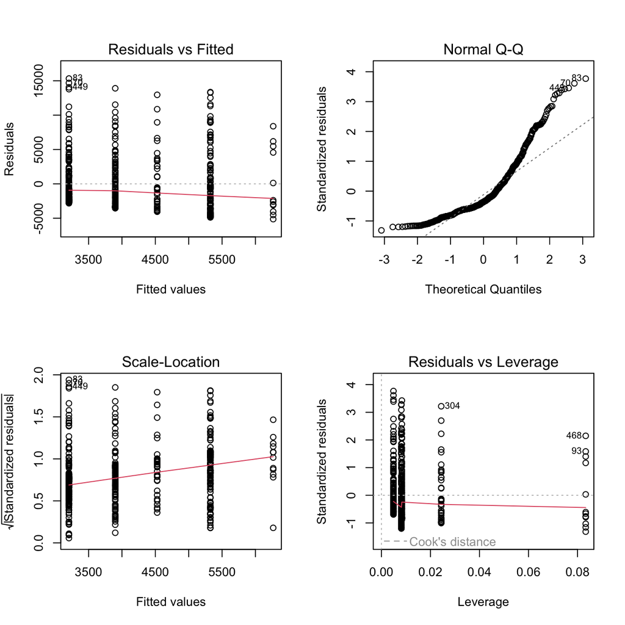

```r
par(mfrow = c(2, 2))
plot(fit)
```

## Multiple regression

1. Fit the main effects model with `carat` and `cut` as predictors of `price`, and display and interpret the summary of the regression results.

```r
fit_main <- lm(price ~ carat + cut, my_diamonds)
summary(fit_main)
```

```
##
## Call:
## lm(formula = price ~ carat + cut, data = my_diamonds)
##
## Residuals:
##     Min      1Q  Median      3Q     Max
## -4189.6  -837.0   -49.8   538.7  7343.8
##
## Coefficients:
##              Estimate Std. Error t value Pr(>|t|)
## (Intercept)   -4121.1      489.0  -8.427 3.91e-16 ***
## carat          8036.6      149.2  53.857  < 2e-16 ***
## cutGood        1531.5      514.6   2.976 0.003060 **
## cutVery Good   1650.6      477.2   3.459 0.000589 ***
## cutPremium     1713.1      473.4   3.619 0.000326 ***
## cutIdeal       1883.2      471.5   3.994 7.47e-05 ***
## ---
## Signif. codes:  0 '***' 0.001 '**' 0.01 '*' 0.05 '.' 0.1 ' ' 1
##
## Residual standard error: 1557 on 494 degrees of freedom
## Multiple R-squared:  0.8615, Adjusted R-squared:  0.8601
## F-statistic: 614.5 on 5 and 494 DF,  p-value: < 2.2e-16
```

2. Make a table of the output of the regression model with `tbl_regression()` (part of the `gtsummary` package) using the following code:

```r
t1 <-
  lm(price ~ carat + cut, my_diamonds) %>%
  tbl_regression()
t1
```

| **Characteristic** | **Beta** | **95% CI**<sup>1</sup> | **p-value** |
| --- | --- | --- | --- |
| carat | 8,037 | 7,743, 8,330 | <0.001 |
| cut |  |  |  |
| Fair | — | — |  |
| Good | 1,531 | 521, 2,542 | 0.003 |
| Very Good | 1,651 | 713, 2,588 | <0.001 |
| Premium | 1,713 | 783, 2,643 | <0.001 |
| Ideal | 1,883 | 957, 2,809 | <0.001 |

<sup>1</sup> CI = Confidence Interval

```r
fit_interact <- lm(price ~ carat * cut, my_diamonds)
summary(fit_interact)
```

```
##
## Call:
## lm(formula = price ~ carat * cut, data = my_diamonds)
##
## Residuals:
##     Min      1Q  Median      3Q     Max
## -4401.7  -807.9   -55.8   549.5  7063.3
##
## Coefficients:
##                    Estimate Std. Error t value Pr(>|t|)
## (Intercept)        -3633.21    1131.22  -3.212  0.00141 **
## carat               7659.10     803.09   9.537  < 2e-16 ***
## cutGood             1037.11    1233.45   0.841  0.40086
## cutVery Good        1408.20    1166.56   1.207  0.22796
## cutPremium           859.38    1168.87   0.735  0.46256
## cutIdeal            1464.59    1149.97   1.274  0.20341
## carat:cutGood        384.82     936.86   0.411  0.68144
## carat:cutVery Good    67.75     861.41   0.079  0.93735
## carat:cutPremium     757.69     846.87   0.895  0.37139
## carat:cutIdeal       275.17     843.95   0.326  0.74453
## ---
## Signif. codes:  0 '***' 0.001 '**' 0.01 '*' 0.05 '.' 0.1 ' ' 1
##
## Residual standard error: 1558 on 490 degrees of freedom
## Multiple R-squared:  0.8624, Adjusted R-squared:  0.8599
## F-statistic: 341.3 on 9 and 490 DF,  p-value: < 2.2e-16
```

```r
t2 <-
  lm(price ~ carat * cut, my_diamonds) %>%
  tbl_regression()
t2
```

| **Characteristic** | **Beta** | **95% CI**<sup>1</sup> | **p-value** |
| --- | --- | --- | --- |
| carat | 7,659 | 6,081, 9,237 | <0.001 |
| cut |  |  |  |
| Fair | — | — |  |
| Good | 1,037 | -1,386, 3,461 | 0.4 |
| Very Good | 1,408 | -884, 3,700 | 0.2 |
| Premium | 859 | -1,437, 3,156 | 0.5 |
| Ideal | 1,465 | -795, 3,724 | 0.2 |
| carat * cut |  |  |  |
| carat * Good | 385 | -1,456, 2,226 | 0.7 |
| carat * Very Good | 68 | -1,625, 1,760 | >0.9 |
| carat * Premium | 758 | -906, 2,422 | 0.4 |
| carat * Ideal | 275 | -1,383, 1,933 | 0.7 |

<sup>1</sup> CI = Confidence Interval

2. What do you notice about the significance of the effects?
- Only the effect of `carat` is significant.
3. Compare the fit of the model with main effects and the model with interaction effects with the `anova` function.

```r
anova(fit_main, fit_interact)
```

```
## Analysis of Variance Table
##
## Model 1: price ~ carat + cut
## Model 2: price ~ carat * cut
##   Res.Df        RSS Df Sum of Sq      F Pr(>F)
## 1    494 1197262713
## 2    490 1189093338  4   8169375 0.8416 0.4992
```

Make a presentation-ready regression table of both models: the main effect model and the interaction effect model with the following code:

```r
# presentation ready regression table

tbl_merge(
  list(t1, t2),
  tab_spanner = c("**Main effects model**", "**Interaction model**")
)
```

| **Characteristic** | **Main effects model** **Beta** | **Main effects model** **95% CI**<sup>1</sup> | **Main effects model** **p-value** | **Interaction model** **Beta** | **Interaction model** **95% CI**<sup>1</sup> | **Interaction model** **p-value** |
| --- | --- | --- | --- | --- | --- | --- |
| carat | 8,037 | 7,743, 8,330 | <0.001 | 7,659 | 6,081, 9,237 | <0.001 |
| cut |  |  |  |  |  |  |
| Fair | — | — |  | — | — |  |
| Good | 1,531 | 521, 2,542 | 0.003 | 1,037 | -1,386, 3,461 | 0.4 |
| Very Good | 1,651 | 713, 2,588 | <0.001 | 1,408 | -884, 3,700 | 0.2 |
| Premium | 1,713 | 783, 2,643 | <0.001 | 859 | -1,437, 3,156 | 0.5 |
| Ideal | 1,883 | 957, 2,809 | <0.001 | 1,465 | -795, 3,724 | 0.2 |
| carat * cut |  |  |  |  |  |  |
| carat * Good |  |  |  | 385 | -1,456, 2,226 | 0.7 |
| carat * Very Good |  |  |  | 68 | -1,625, 1,760 | >0.9 |
| carat * Premium |  |  |  | 758 | -906, 2,422 | 0.4 |
| carat * Ideal |  |  |  | 275 | -1,383, 1,933 | 0.7 |

<sup>1</sup> CI = Confidence Interval

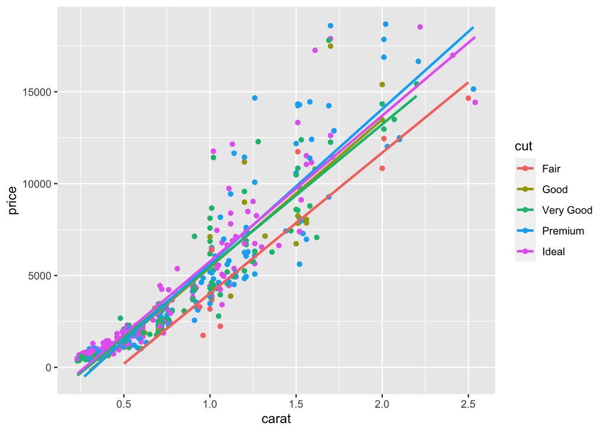

```r
ggplot(my_diamonds, aes(carat, price, col = cut))+
  geom_point() +
  geom_smooth(method = "lm", se = F)
```

- The regression lines are separated, so there are some main effects.
- They are almost parallel, so no interactions.

End of practical